# Introduction à l’analyse Biographique des avec R

Correction TPI: analyse sorties du premier emploi

Author

Affiliation

[Marc Thevenin](https://github.com/mthevenin)

[Institut National d’Etudes Démographiques](https://www.ined.fr/)

Published

October 9, 2023

```r
options(scipen=999)  # empêcher le format scientifique
options(show.signif.stars=FALSE)
```

# 1 Packages

**Analyse standard**  
Le package `survival` permet de réaliser un grand nombre d’analyses des durées pour un évènement unique (risques non concurrents et non récurrent): **Kaplan Meier**, **modèles semiparamétrique** (Cox), **modèle paramétriques**……

**Analyse à durée discrète/groupée**  
Pour les modèles à durée discrète/groupée, on utilisera la fonction `glm`, intégrée à R. La fonction `uncount` du package `tydir` permet d’allonger, si nécessaire, la base en format long. La fonction `survsplit` du package peut, sous certaines conditions, réaliser cette opération.

**Amélioration des outputs**

- Graphique: Pour l’esthétique, on peut également utiliser le package `survminer` (ex: fonction de survie de type ggplot2 et présentation des risk-ratio après un modèle de Cox). Le package `survminer` permet aussi de faire des tests du log-rank qui comparent des fonctions de survie 2 à 2 à partir de variables à plus de deux modalités.
- Outputs:
  - **jtools**: pour les modèles estimés avec la fonction glm (modèles à temps discret) ou coxph: package `RecordLinkage`, et fonction `summ` du package `jtools`. Pas d’utilisation possible pour la fonction `multinom` (risque concurrent avec un modèle logistique multinomial).
  - **gtsummary**: fonction **`tlb_regression`**, très répandue. Permet de sortir un output pour le modèle multinomial, mais en format long,

**Installation des packages**

```r
#install.packages("survival")
#install.packages("survminer")
#install.packages("survRM2")
#install.packages("rms")
#install.packages("tidyr")
#install.packages("gtools")
#install.packages("jtools")
#install.packages("RecordLinkage")
#install.packages("gtsummary")
#install.packages("cmprsk")
#install.packages("nnet")

library(survival)
library(survminer)
library(survRM2)
library(tidyr)
library(gtools)
library(jtools)
library(RecordLinkage)
library(gtsummary)
library(cmprsk)
library(nnet)
```

# 2 La base et la construction des variables d’analyse

## 2.1 La base

Base **tp_activite**: Analyse de la durée de la **première séquence d’emploi(s)** de femmes nées avant 1951.

```r
act <- read.csv("D:/D/Marc/SMS/FORMATIONS/2022/Durée2/tp/bio et entourage/sortie emploi [tp strasbourg]/tp_activite.csv")
```

Il s’agit de la base “prête à l’analyse. A l’origine les données sont dans une base en format *âges-séquences* qui a du être mise en forme. Un programme de mise en forme, avec étapes prudentes, est donné à la fin du document.

**Variables**

Variable

**ident**

Identifiant de la personne

**diplome**

Niveau de diplôme

- 1 = inférieur au bac
- 2 = bac
- 3 = supérieur au bac

**gene**

Génération

- 1 = avant 1940
- 2 = 1940-1940
- 3 = 1945-1950

**csp**

Csp représentative

- artisane ou agricultrice
- cadre
- employée
- ouvrière
- profession intermédiaire

**enf**

Avoir eu un enfant pendant la période d’observation

- 0: non
- 1: oui

**typinact**

type de sortie de l’emploi

- 0: pas de sortie de l’emploi
- inactivité-retour au foyer
- Autres (chômage, maladie…)

**aanenf**

Age à la de naissance de l’enfant

- 0: pas d’enfant
- Age à la naissance

**ageact**

Age au premier emploi

**ageinact**

Age à la sortie de l’emploi

- 0: pas de sortie de l’emploi
- Age à la sortie

**ageret**

Age à la retraite

- 0: pas à la retraite au moment de l’enquête
- Age à la retraite

**age_enq**

Age au moment de l’enquête

## 2.2 Construction des variables d’analyse

**Variable censure-évènement**

```r
act$d = ifelse(act$ageinact>0, 1, 0)
```

**Variable de durée**

Rappel sur la notion de censure: la durée d’observation est inférieure à la durée d’exposition au risque.  
Ici, on doit aussi prendre en compte la situation inverse. Des femmes ont toujours occupé un emploi et sont sorties du marché du travail uniquement au moment de la retraite. On ne peut plus les considérer comme exposées au risque après la retraite sinon la durée d’observation est supérieure à la durée d’exposition. On peut confondre ces situations comme des censures à droite (0) si on suppose que l’âge à la prise de la retraite n’est pas informative. Quelque part on fait une hypothèse d’indépendance entre le passage à la retraite et les autres causes de sorties. Potentiellement discutable, mais le passage à la retraite va se situer a des âges plutôt élevé.

Principe:

- Le début de l’exposition au risque est *ageact*
- On doit calculer la fin de l’exposition: sortie de l’emploi hors retraite , à la retraite ou simplement sortie de l’observation avec une censure à droite (âge à l’enquête).
- On calcule la durée. Avec des données discrètes/groupées, je prends toute la longueur de la durée et non la simple différence entre 2 points: fin - début + 1. On évite d’observer des évènements avec $t=0$ et on facilite certaines manipulations, en particulier celles relatives aux covariables non fixes issues d’autres bases biographiques.

```r
act$fin = ifelse(act$d==1, act$ageinact, ifelse(act$ageret>0, act$ageret, act$age_enq))
act$dur = act$fin - act$ageact + 1
```

# 3 Analyse non paramétrique: Kaplan Meier et tests du log-rank

## 3.1 Estimation

**Fonctions `survfit` `survdiff`**

```r
km = survfit(Surv(dur,d)~1, data=act)
summary(km)
```

```
Call: survfit(formula = Surv(dur, d) ~ 1, data = act)

 time n.risk n.event survival std.err lower 95% CI upper 95% CI
    2   1437      31    0.978 0.00383        0.971        0.986
    3   1406      70    0.930 0.00674        0.917        0.943
    4   1336      68    0.882 0.00850        0.866        0.899
    5   1266      80    0.827 0.00999        0.807        0.846
    6   1186      57    0.787 0.01081        0.766        0.808
    7   1129      68    0.740 0.01158        0.717        0.763
    8   1060      69    0.691 0.01219        0.668        0.716
    9    991      54    0.654 0.01256        0.630        0.679
   10    937      47    0.621 0.01281        0.596        0.647
   11    888      56    0.582 0.01303        0.557        0.608
   12    832      28    0.562 0.01310        0.537        0.588
   13    804      30    0.541 0.01316        0.516        0.568
```

[output cut: 32 more lines]

```r
km
```

```
Call: survfit(formula = Surv(dur, d) ~ 1, data = act)

        n events median 0.95LCL 0.95UCL
[1,] 1437    919     16      14      18
```

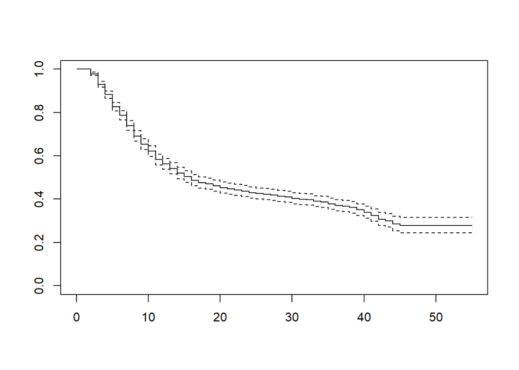

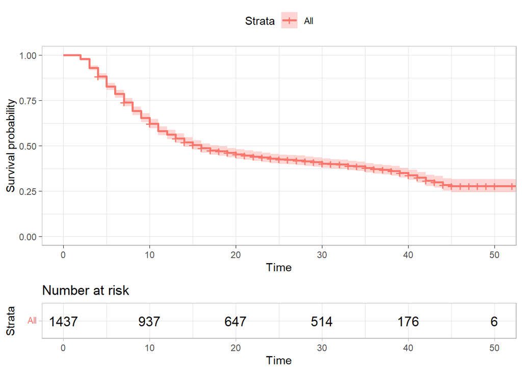

```r
plot(km)
ggsurvplot(km, risk.table=TRUE, ggtheme=theme_light(),)
```

## 3.2 Comparaison de fonctions de survie

**Niveau de diplome**

```r
km = survfit(Surv(dur,d)~diplome, data=act)
# summary(km)
km
```

```
Call: survfit(formula = Surv(dur, d) ~ diplome, data = act)

            n events median 0.95LCL 0.95UCL
diplome=1 915    626     15      13      16
diplome=2 203    110     33      17      40
diplome=3 319    183     17      11      33
```

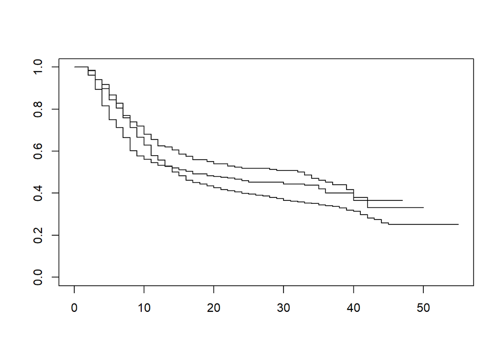

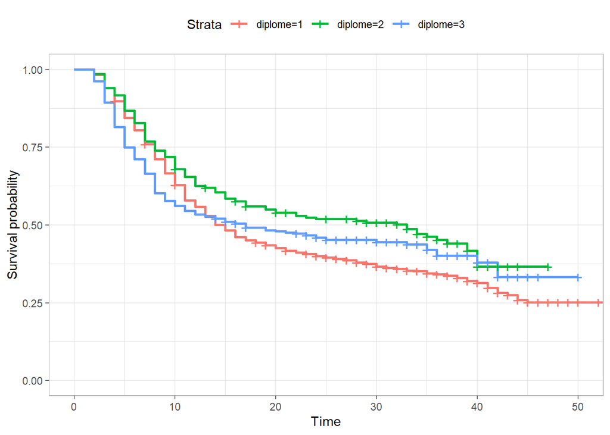

```r
plot(km)
ggsurvplot(km, ggtheme=theme_light(),)
```

**CSP**

```r
km = survfit(Surv(dur,d)~csp, data=act)
# summary(km)
km
```

```
Call: survfit(formula = Surv(dur, d) ~ csp, data = act)

                   n events median 0.95LCL 0.95UCL
csp=Artisans agr  49     39     11       8      25
csp=Cadres       270    129     40      33      NA
csp=Employes     637    461     14      12      16
csp=Ouvriers      75     62     11       8      13
csp=Profs interm 406    228     21      14      37
```

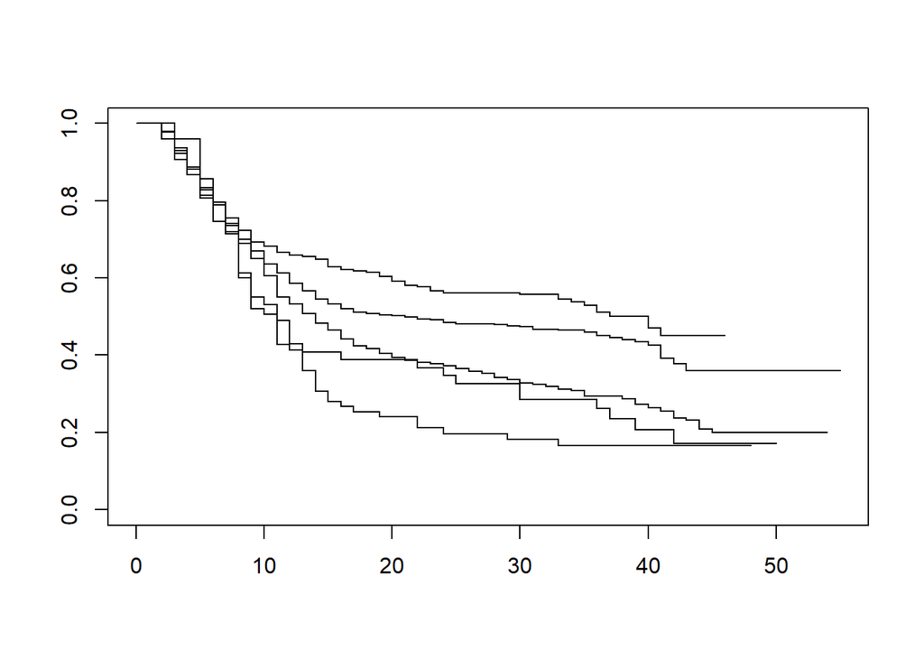

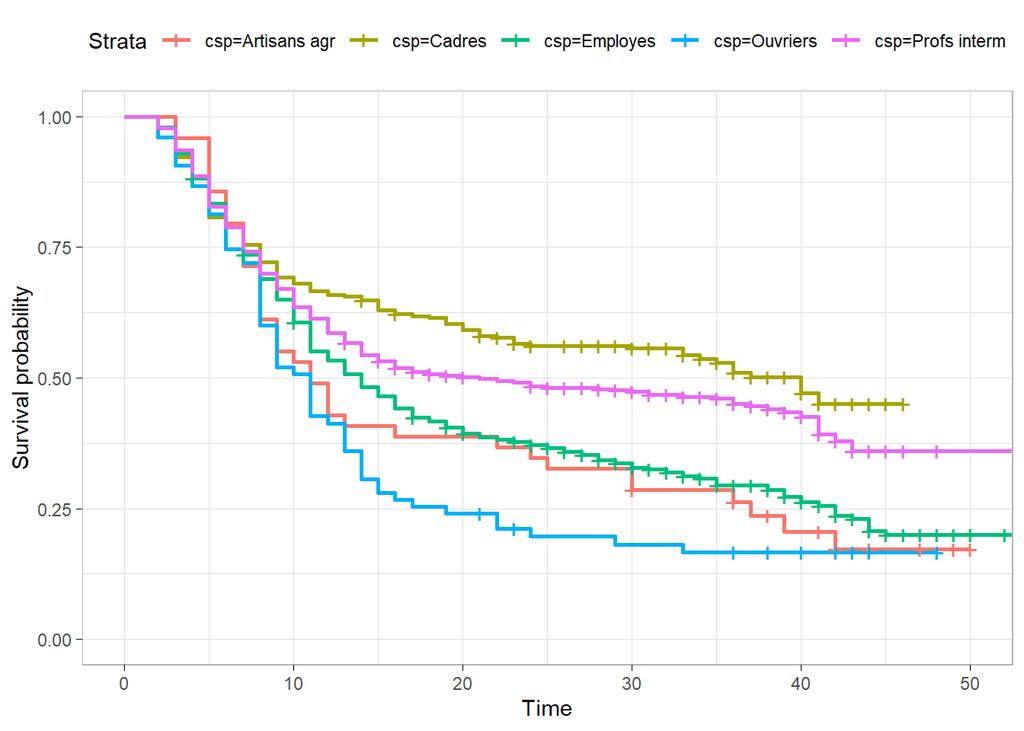

```r
plot(km)
ggsurvplot(km, ggtheme=theme_light(),)
```

**Générations**

```r
km = survfit(Surv(dur,d)~gene, data=act)
# summary(km)
km
```

```
Call: survfit(formula = Surv(dur, d) ~ gene, data = act)

         n events median 0.95LCL 0.95UCL
gene=1 492    335     15      13      18
gene=2 399    266     13      11      18
gene=3 546    318     19      16      27
```

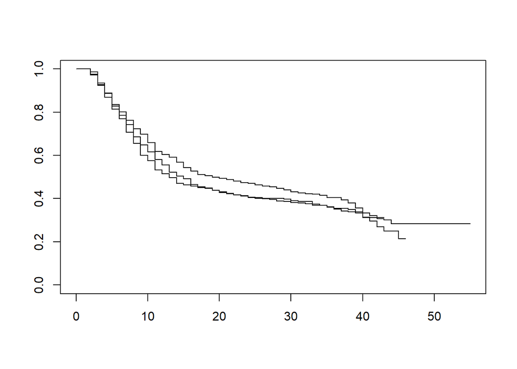

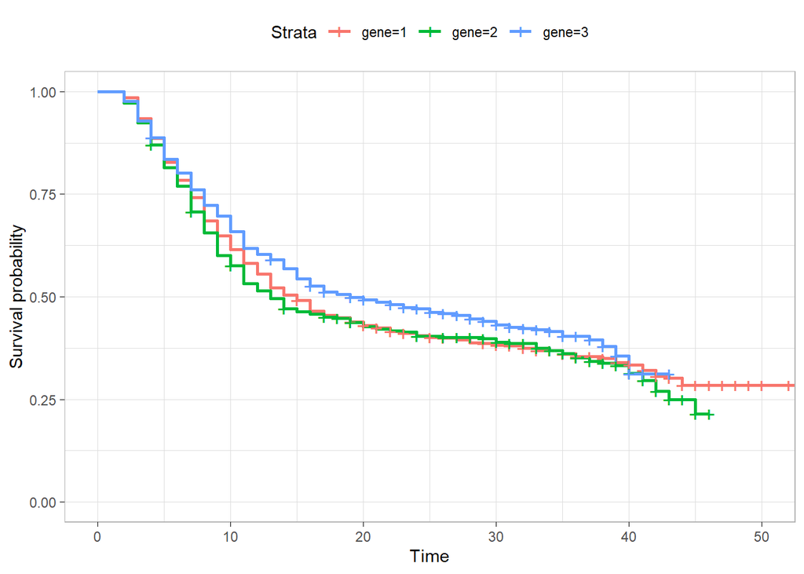

```r
plot(km)
ggsurvplot(km, ggtheme=theme_light(),)
```

### 3.2.1 Test du log-rank (niveau de diplome)

Attention: sensible à l’hypothèse de risques proportionnels (constance des risks ratios dans le temps => cf modèle de Cox) Hypothèse nulle : les fonctions de survie sont homogènes => par déduction rapports des risques toujours égaux à 1 / Hypothèse alternative: les fonctions de survie ne sont pas homogènes. La probabilité reportée (p-value) est appelée “risque de première espèce”

Test conseillé: utiliser l’option `rho=1`, pas sensible à la distribution des censures à droite, dit test de **Peto-Peto**.

```r
survdiff(Surv(dur,d)~diplome,data=act, rho=0)
```

```
Call:
survdiff(formula = Surv(dur, d) ~ diplome, data = act, rho = 0)

            N Observed Expected (O-E)^2/E (O-E)^2/V
diplome=1 915      626      594    1.7463     5.196
diplome=2 203      110      138    5.6401     6.949
diplome=3 319      183      187    0.0994     0.131

 Chisq= 7.9  on 2 degrees of freedom, p= 0.02
```

```r
survdiff(Surv(dur,d)~diplome,data=act, rho=1)
```

```
Call:
survdiff(formula = Surv(dur, d) ~ diplome, data = act, rho = 1)

            N Observed Expected (O-E)^2/E (O-E)^2/V
diplome=1 915    420.8    411.3     0.223      0.88
diplome=2 203     75.7     95.3     4.027      6.68
diplome=3 319    141.6    131.5     0.763      1.34

 Chisq= 7.1  on 2 degrees of freedom, p= 0.03
```

Si plus de deux modalités, il est pertinent de tester les fonctions de survie 2 à 2: fonction `pairwise_survdiff` (même syntaxe que `surdiff`)

```r
pairwise_survdiff(Surv(dur,d)~diplome,data=act, rho=1)
```

```
    Pairwise comparisons using Peto & Peto test

data:  act and diplome

  1     2
2 0.031 -
3 0.516 0.031

P value adjustment method: BH
```

### 3.2.2 Comparaison des RMST (niveau de diplome)

RMST: Restricted mean of survival time.

- Intéressant pour des démographes, on compare des espérances de survie (séjour) partielles.
- La durée est bornée au moment du dernier évènement observé. Lorsqu’on compare plusieurs courbes, on prend celle où la durée du dernier évènement est la plus courte.
- Encore peu diffusé (hélas) en sciences sociales.
- Défaut de la fonction R: créer une variable nommée *arm* identique à la variable discrete, mais codée (0,1).

Packgage `survRM2` indépendant de `survival`.  
Exemple pour comparer les 2 premiers niveaux de diplome (inférieur au bac versus bac).

```r
rmst12=act[act$diplome!=3,]
rmst12$arm=ifelse(rmst12$diplome==1,1,0)
a=rmst2(rmst12$dur, rmst12$d, rmst12$arm)
print(a)
```

```
The truncation time, tau, was not specified. Thus, the default tau  47  is used.

Restricted Mean Survival Time (RMST) by arm
               Est.    se lower .95 upper .95
RMST (arm=1) 23.041 0.582    21.901    24.181
RMST (arm=0) 27.250 1.309    24.683    29.816


Restricted Mean Time Lost (RMTL) by arm
               Est.    se lower .95 upper .95
RMTL (arm=1) 23.959 0.582    22.819    25.099
RMTL (arm=0) 19.750 1.309    17.184    22.317


Between-group contrast
                       Est. lower .95 upper .95     p
RMST (arm=1)-(arm=0) -4.209    -7.017    -1.401 0.003
RMST (arm=1)/(arm=0)  0.846     0.760     0.940 0.002
RMTL (arm=1)/(arm=0)  1.213     1.056     1.393 0.006
```

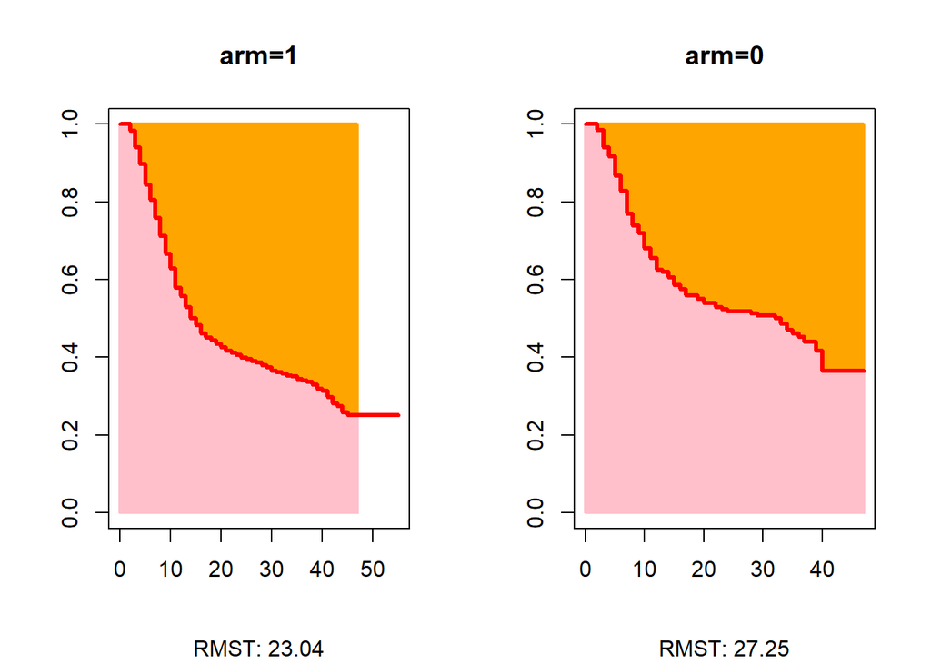

```r
plot(a)
```

PS: *c’est la comparaison qui renvoyait un msg d’erreur mercredi après-midi. La fatigue a surement jouée son rôle, j’avais laissé la valeur 3 dans `ifelse` alors qu’il n’y avait plus d’obseravation pour cette modalité*.

# 4 Analyse semi-paramétrique: modèle à risques proportionnel de Cox

**Rappel**: l’hypothèse PH signifie que le rapport des risques est constant pendant la durée d’observation.

Avec une seule covariable X, un modèle à risque proportionnel s’écrit:
$$h(t_i | X) = h_0(t_i)\times e^{b\times X}$$

Soit 2 observations A et B. Le rapport des risques entre A et B s’écrit:
$$\frac{h(t_i |X_A)}{h(t_i |X_B)}= \frac{e^{b\times X_A}}{e^{b\times X_b}}= e^{b\times (X_A-X_B)}$$

**Fonctions `coxph` `coxzph` `survsplit`**

## 4.1 Estimation

Penser à mettre les covariables en facteurs si nécessaire (ou `factor(nom variable)` dans le modèle) et prévoir les changements de références (fonction `relevel`).

```r
act$gene = as.factor(act$gene)
act$gene =  relevel(act$gene, ref = "2")
act$csp  = as.factor(act$csp)
act$csp  =  relevel(act$csp,  ref = "Cadres")
act$diplome  = as.factor(act$diplome)
act$diplome =  relevel(act$diplome,  ref = 2)
```

```r
coxfit = coxph(Surv(dur,d) ~  gene + csp + diplome, data=act)
summary(coxfit)
```

```
Call:
coxph(formula = Surv(dur, d) ~ gene + csp + diplome, data = act)

  n= 1437, number of events= 919

                    coef exp(coef) se(coef)      z       Pr(>|z|)
gene1           -0.13753   0.87151  0.08337 -1.650        0.09904
gene3           -0.19451   0.82324  0.08356 -2.328        0.01992
cspArtisans agr  0.79870   2.22264  0.18885  4.229 0.000023455201
cspEmployes      0.72507   2.06488  0.11937  6.074 0.000000001248
cspOuvriers      1.05506   2.87214  0.17004  6.205 0.000000000548
cspProfs interm  0.35252   1.42265  0.11755  2.999        0.00271
diplome1         0.04667   1.04778  0.11013  0.424        0.67171
diplome3         0.37376   1.45319  0.12612  2.964        0.00304

                exp(coef) exp(-coef) lower .95 upper .95
gene1              0.8715     1.1474    0.7401    1.0262
gene3              0.8232     1.2147    0.6989    0.9697
cspArtisans agr    2.2226     0.4499    1.5350    3.2183
cspEmployes        2.0649     0.4843    1.6341    2.6092
cspOuvriers        2.8721     0.3482    2.0581    4.0082
cspProfs interm    1.4227     0.7029    1.1299    1.7913
diplome1           1.0478     0.9544    0.8444    1.3002
diplome3           1.4532     0.6881    1.1349    1.8607

Concordance= 0.574  (se = 0.01 )
Likelihood ratio test= 69.18  on 8 df,   p=0.000000000007
Wald test            = 66.89  on 8 df,   p=0.00000000002
Score (logrank) test = 68.01  on 8 df,   p=0.00000000001
```

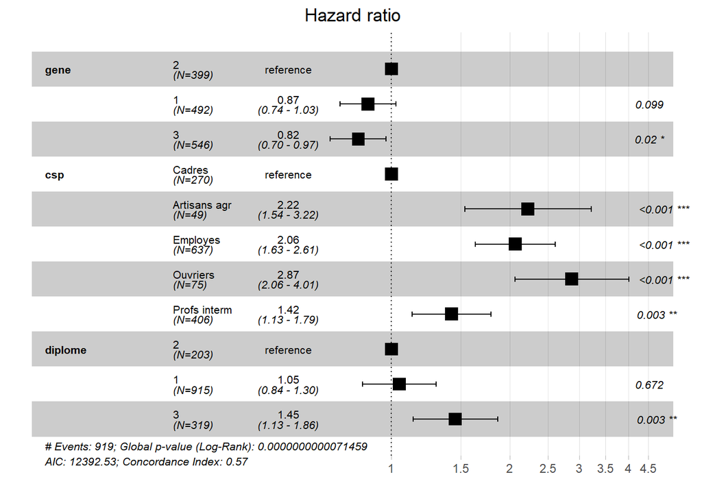

```r
ggforest(coxfit)
```

## 4.2 Test de l’hypothèse de risques proportionnels

### 4.2.1 Test sur les résidus de Schoenfeld

**v3 - test exact (gls)**: La fonction utilisée est `cox.zph` **v2 - test simplifié (ols)** : la fonction utilisée est `cox.zphold` (à récupérer et à charger). Je continue de conseiller à utiliser cette version du test.

Le test peut utiliser plusieurs formes paramétriques de la durée. Par défaut la fonction utilise $f(t)=1-S(t)$, soit le complémentaire de l’estimateur de Kaplan-Meier (option `transform=“km”`). Autres fonctions $f(t)=t$ (`transform=“identity”`).

Avec la v2:

```r
source("D:/D/Marc/SMS/FORMATIONS/2022/Durée2/a distribuer/cox.zphold.R")
```

```r
cox.zphold(coxfit)
```

```
                    rho   chisq          p
gene1           -0.0112  0.1161 0.73328057
gene3            0.0307  0.8624 0.35305484
cspArtisans agr  0.0481  2.1434 0.14318292
cspEmployes      0.0458  2.0459 0.15261533
cspOuvriers      0.0294  0.8157 0.36643658
cspProfs interm -0.0151  0.2196 0.63935110
diplome1         0.0036  0.0121 0.91247404
diplome3        -0.0958  8.8535 0.00292533
GLOBAL               NA 42.3314 0.00000117
```

```r
cox.zphold(coxfit, transform="identity")
```

```
                    rho  chisq       p
gene1           -0.0309  0.889 0.34586
gene3            0.0275  0.691 0.40578
cspArtisans agr  0.0339  1.068 0.30143
cspEmployes      0.0291  0.826 0.36339
cspOuvriers     -0.0066  0.041 0.83949
cspProfs interm -0.0357  1.224 0.26857
diplome1        -0.0162  0.245 0.62091
diplome3        -0.0779  5.861 0.01548
GLOBAL               NA 24.836 0.00166
```

Avec la v3:

```r
cox.zph(coxfit, terms=FALSE)
```

```
                   chisq df            p
gene1            0.00478  1        0.945
gene3            0.60359  1        0.437
cspArtisans agr  1.10591  1        0.293
cspEmployes     15.45130  1 0.0000846587
cspOuvriers      0.89068  1        0.345
cspProfs interm  8.30586  1        0.004
diplome1        23.54565  1 0.0000012198
diplome3        32.99485  1 0.0000000092
GLOBAL          43.35937  8 0.0000007516
```

```r
cox.zph(coxfit, terms=FALSE, transform="identity")
```

```
                 chisq df        p
gene1            1.116  1  0.29083
gene3            1.947  1  0.16294
cspArtisans agr  0.859  1  0.35392
cspEmployes     10.786  1  0.00102
cspOuvriers      0.138  1  0.70987
cspProfs interm  7.114  1  0.00765
diplome1         8.941  1  0.00279
diplome3        16.348  1 0.000053
GLOBAL          26.963  8  0.00072
```

### 4.2.2 Modèle de Cox et intéraction avec la durée

- Prérequis: les variables discrètes doivent être sous forme d’indicatrices (0,1).
- Permet de modifier le modèle, de le présenter sans l’hypothèse de constance du rapport de risque et d’enrichir l’interprétation.
- Attention à l’interpétation du terme d’interaction, ce n’est pas un rapport de risque mais un rapport de rapports de risque.

On peut directement introduire cette intéraction, avec le choix de la paramétrisation de la durée, dans la fonction `coxph`.

```r
act$dipl1 = ifelse(act$diplome==1, 1,0)
# act$dipl2 = ifelse(act$diplome==2, 1,0) Pas nécessaire car c'est la référence
act$dipl3 = ifelse(act$diplome==3, 1,0)

coxfit2 = coxph(Surv(dur, d) ~ gene + csp + dipl1 + dipl3  + tt(dipl3), data = act, tt = function(x, t, ...) x*t)
summary(coxfit2)
```

```
Call:
coxph(formula = Surv(dur, d) ~ gene + csp + dipl1 + dipl3 + tt(dipl3),
    data = act, tt = function(x, t, ...) x * t)

  n= 1437, number of events= 919

                    coef exp(coef) se(coef)      z       Pr(>|z|)
gene1           -0.12615   0.88148  0.08345 -1.512        0.13060
gene3           -0.19547   0.82245  0.08356 -2.339        0.01932
cspArtisans agr  0.79385   2.21189  0.18867  4.208 0.000025819776
cspEmployes      0.71162   2.03729  0.11872  5.994 0.000000002046
cspOuvriers      1.05756   2.87934  0.16977  6.229 0.000000000468
cspProfs interm  0.33875   1.40320  0.11734  2.887        0.00389
dipl1            0.04848   1.04968  0.11011  0.440        0.65973
dipl3            0.88508   2.42317  0.17238  5.134 0.000000282986
tt(dipl3)       -0.05013   0.95111  0.01259 -3.980 0.000068799501

                exp(coef) exp(-coef) lower .95 upper .95
gene1              0.8815     1.1345    0.7485    1.0381
gene3              0.8225     1.2159    0.6982    0.9688
cspArtisans agr    2.2119     0.4521    1.5281    3.2016
cspEmployes        2.0373     0.4908    1.6144    2.5710
cspOuvriers        2.8793     0.3473    2.0643    4.0161
cspProfs interm    1.4032     0.7127    1.1149    1.7660
dipl1              1.0497     0.9527    0.8459    1.3025
dipl3              2.4232     0.4127    1.7284    3.3972
tt(dipl3)          0.9511     1.0514    0.9279    0.9749

Concordance= 0.59  (se = 0.01 )
Likelihood ratio test= 88.29  on 9 df,   p=0.000000000000004
Wald test            = 83.36  on 9 df,   p=0.00000000000003
Score (logrank) test = 84.6  on 9 df,   p=0.00000000000002
```

## 4.3 Introduction d’une variable dynamique

On regardera le cas d’une variable de type binaire.

Question: quel est l’effet de la naissance d’un (premier) enfant sur le risque de sortie de l’emploi?

**Estimation du modèle en considérant la naissance comme une variable fixe (variable enf)**

```r
coxfit3 = coxph(Surv(dur, d) ~ gene + csp + diplome + enf, data = act)
summary(coxfit3)
```

```
Call:
coxph(formula = Surv(dur, d) ~ gene + csp + diplome + enf, data = act)

  n= 1437, number of events= 919

                    coef exp(coef) se(coef)      z        Pr(>|z|)
gene1           -0.11143   0.89455  0.08354 -1.334        0.182228
gene3           -0.20483   0.81479  0.08359 -2.450        0.014273
cspArtisans agr  0.68793   1.98959  0.18911  3.638        0.000275
cspEmployes      0.67699   1.96794  0.12006  5.639 0.0000000171327
cspOuvriers      0.96649   2.62871  0.17056  5.667 0.0000000145567
cspProfs interm  0.32627   1.38579  0.11792  2.767        0.005660
diplome1         0.02963   1.03007  0.11052  0.268        0.788620
diplome3         0.39445   1.48357  0.12655  3.117        0.001827
enf              0.81318   2.25506  0.12314  6.604 0.0000000000401

                exp(coef) exp(-coef) lower .95 upper .95
gene1              0.8945     1.1179    0.7594    1.0537
gene3              0.8148     1.2273    0.6917    0.9598
cspArtisans agr    1.9896     0.5026    1.3734    2.8823
cspEmployes        1.9679     0.5081    1.5553    2.4900
cspOuvriers        2.6287     0.3804    1.8818    3.6722
cspProfs interm    1.3858     0.7216    1.0998    1.7461
diplome1           1.0301     0.9708    0.8295    1.2792
diplome3           1.4836     0.6740    1.1577    1.9012
enf                2.2551     0.4434    1.7715    2.8706

Concordance= 0.605  (se = 0.01 )
Likelihood ratio test= 123.5  on 9 df,   p=<0.0000000000000002
Wald test            = 107.3  on 9 df,   p=<0.0000000000000002
Score (logrank) test = 111.3  on 9 df,   p=<0.0000000000000002
```

### 4.3.1 Retour sur l’estimation du modèle de Cox

La base qui sert à l’estimation est splittée aux temps d’évènement.  
Pour transformer la base d’origine on utilise la fonction `survsplit`. Au préalable on doit créer un vecteur donnant tous les temps d’évènement observés (fonction `cut`).

**Récupération des durées d’évènement**

```r
cut= unique(act$dur[act$d == 1])
```

**Transformation de la base**

La nouvelle base est nommée *tvc*. Il est nécessaire d’avoir une variable qui indique le début de l’intervalle de temps entre deux évènements (ici on va l’appelé *dur0*).

```r
tvc = survSplit(data = act, cut = cut, end = "dur", start = "dur0", event = "d")
```

**Estimation du modèle**

Avec R, lorsque la base est splittée, on ne renseigne pas la durée mais le début et la fin de chaque intervalle pour utiliser la fonction `coxph`.  
On vérifie que le modèle estimé avec cette base splittée est identique au précédent.

```r
coxfit = coxph(Surv(dur0, dur, d) ~ gene + csp + diplome + enf, data = tvc)
summary(coxfit3)
```

```
Call:
coxph(formula = Surv(dur, d) ~ gene + csp + diplome + enf, data = act)

  n= 1437, number of events= 919

                    coef exp(coef) se(coef)      z        Pr(>|z|)
gene1           -0.11143   0.89455  0.08354 -1.334        0.182228
gene3           -0.20483   0.81479  0.08359 -2.450        0.014273
cspArtisans agr  0.68793   1.98959  0.18911  3.638        0.000275
cspEmployes      0.67699   1.96794  0.12006  5.639 0.0000000171327
cspOuvriers      0.96649   2.62871  0.17056  5.667 0.0000000145567
cspProfs interm  0.32627   1.38579  0.11792  2.767        0.005660
diplome1         0.02963   1.03007  0.11052  0.268        0.788620
diplome3         0.39445   1.48357  0.12655  3.117        0.001827
enf              0.81318   2.25506  0.12314  6.604 0.0000000000401

                exp(coef) exp(-coef) lower .95 upper .95
gene1              0.8945     1.1179    0.7594    1.0537
gene3              0.8148     1.2273    0.6917    0.9598
cspArtisans agr    1.9896     0.5026    1.3734    2.8823
cspEmployes        1.9679     0.5081    1.5553    2.4900
cspOuvriers        2.6287     0.3804    1.8818    3.6722
cspProfs interm    1.3858     0.7216    1.0998    1.7461
diplome1           1.0301     0.9708    0.8295    1.2792
diplome3           1.4836     0.6740    1.1577    1.9012
enf                2.2551     0.4434    1.7715    2.8706

Concordance= 0.605  (se = 0.01 )
Likelihood ratio test= 123.5  on 9 df,   p=<0.0000000000000002
Wald test            = 107.3  on 9 df,   p=<0.0000000000000002
Score (logrank) test = 111.3  on 9 df,   p=<0.0000000000000002
```

### 4.3.2 Construction de la TVC

Comme on dispose de l’information sur l’âge à la naissance de l’enfant:  
Si *enfant*==1 & *age*>=*aanenf*, tvc=1, 0 sinon.  
L’âge de la répondante sur chaque année d’observation n’existe pas dans la base puisqu’on a une variable de durée. On doit construire cette variable pour comparer l’âge de la personne sur toute la période d’observation à l’âge à la naissance du premier enfant.

```r
tvc$age= tvc$ageact + tvc$dur0
```

```r
tvc$tvc = tvc$enf
tvc$tvc = ifelse(tvc$tvc==1 & tvc$age>=tvc$aanenf,1,0)
head(tvc, n=12)
```

```
   ident diplome gene      csp enf typinact aanenf ageact ageinact ageret
1    101       1    1 Ouvriers   1        2     26     14       26      0
2    101       1    1 Ouvriers   1        2     26     14       26      0
3    101       1    1 Ouvriers   1        2     26     14       26      0
4    101       1    1 Ouvriers   1        2     26     14       26      0
5    101       1    1 Ouvriers   1        2     26     14       26      0
6    101       1    1 Ouvriers   1        2     26     14       26      0
7    101       1    1 Ouvriers   1        2     26     14       26      0
8    101       1    1 Ouvriers   1        2     26     14       26      0
9    101       1    1 Ouvriers   1        2     26     14       26      0
10   101       1    1 Ouvriers   1        2     26     14       26      0
11   101       1    1 Ouvriers   1        2     26     14       26      0
12   101       1    1 Ouvriers   1        2     26     14       26      0
   age_enq fin dipl1 dipl3 dur0 dur d age tvc
1       61  26     1     0    0   2 0  14   0
2       61  26     1     0    2   3 0  16   0
3       61  26     1     0    3   4 0  17   0
4       61  26     1     0    4   5 0  18   0
5       61  26     1     0    5   6 0  19   0
6       61  26     1     0    6   7 0  20   0
7       61  26     1     0    7   8 0  21   0
8       61  26     1     0    8   9 0  22   0
9       61  26     1     0    9  10 0  23   0
10      61  26     1     0   10  11 0  24   0
11      61  26     1     0   11  12 0  25   0
12      61  26     1     0   12  13 1  26   1
```

**Remarque: important**  
La naissance d’un enfant peut avoir lieu après la sortie d’activité. Cela pose un problème car avec les modèles de durée on stoppe l’observation après l’évènement. Par principe la cause précède toujours l’effet, mais dans ce cas on observe la cause après. Il y a un risque que l’estimation soir biaisée.  
Lorsque que la cause est observée avant l’évènement, on parle d’effet d’adaptation, lorsque la manifestation de la cause est observée après l’évènement on parle d’effet d’anticipation. Il n’en reste pas moins que la cause réelle est toujours antérieure à l’évènement, mais elle n’est pas observée. Certains modèles tente de résoudre ce problème, mais ils sont particulièrement complexes (et peu diffusés).  
On n’a pas ce problème avec l’impact des greffes (analyse transplantation), car l’évènement étudier est complètement absorbant (décès).

### 4.3.3 Estimation du modèle

```r
coxfit3 = coxph(Surv(dur0, dur, d) ~ gene + csp + diplome + tvc, data = tvc)
summary(coxfit3)
```

```
Call:
coxph(formula = Surv(dur0, dur, d) ~ gene + csp + diplome + tvc,
    data = tvc)

  n= 27742, number of events= 919

                    coef exp(coef) se(coef)      z             Pr(>|z|)
gene1           -0.05154   0.94977  0.08364 -0.616              0.53777
gene3           -0.21045   0.81022  0.08354 -2.519              0.01176
cspArtisans agr  0.79742   2.21980  0.18920  4.215         0.0000250048
cspEmployes      0.69243   1.99857  0.12107  5.719         0.0000000107
cspOuvriers      1.01370   2.75579  0.17075  5.937         0.0000000029
cspProfs interm  0.32316   1.38149  0.11890  2.718              0.00657
diplome1         0.09618   1.10095  0.11041  0.871              0.38370
diplome3         0.38124   1.46410  0.12728  2.995              0.00274
tvc              1.13565   3.11318  0.08035 14.134 < 0.0000000000000002

                exp(coef) exp(-coef) lower .95 upper .95
gene1              0.9498     1.0529    0.8062    1.1190
gene3              0.8102     1.2342    0.6879    0.9543
cspArtisans agr    2.2198     0.4505    1.5320    3.2163
cspEmployes        1.9986     0.5004    1.5764    2.5338
cspOuvriers        2.7558     0.3629    1.9720    3.8511
cspProfs interm    1.3815     0.7239    1.0943    1.7440
diplome1           1.1010     0.9083    0.8867    1.3669
diplome3           1.4641     0.6830    1.1409    1.8789
tvc                3.1132     0.3212    2.6596    3.6442

Concordance= 0.664  (se = 0.01 )
Likelihood ratio test= 284.7  on 9 df,   p=<0.0000000000000002
Wald test            = 264.9  on 9 df,   p=<0.0000000000000002
Score (logrank) test = 275.8  on 9 df,   p=<0.0000000000000002
```

# 5 Modèle (logistique) à temps discret

- Par définition ce n’est pas un modèle à risque proportionnel, mais à odds proportionnels. Toutefois en situation de rareté, l’Odds converge vers une probabilité, qui est une mesure du risque (ici une probabilité conditionnelle).
- Le modèle à temps discret est de type paramétrique.
- Il est moins contraignant que le modèle de Cox si l’hypothèse de proportionnalité n’est pas respectée, car le modèle est ajusté par une fonction de la durée.
- La base de données doit être transformée ici en format long (cf survsplit): aux temps d’observation ou sur des intervalles de temps.

Avec un lien logistique, le modèle à temps discret, avec seulement des covariables fixes, peut s’écrire:

$$log\left[\frac{P(Y_t=1\ |\ Y_{t-1}=0,X_k)}{1-P(Y_t=1\ |\ Y_{t-1}=0,X_k)}\right]= a_0 + \sum_{p}a_pf(t_p)+\sum_{k}b_kX_k$$

## 5.1 Transformation de la base

*Allongement de la base et variables d’analyse*

On va utiliser la fonction `uncount` du package `tidyr` qui va répliquer les observations selon la valeur de la variable de durée. Avant, on génère une variable mirroir de la variable *mois* qui sera supprimée avec l’exécution d’**`uncount`**, et une variable x=1 pour créer la variable de durée sous forme de compteur.

```r
act$dur2 = act$dur
act$x=1
td = uncount(data=act,dur)
head(td, n=13)
```

```
   ident diplome gene      csp enf typinact aanenf ageact ageinact ageret
1    101       1    1 Ouvriers   1        2     26     14       26      0
2    101       1    1 Ouvriers   1        2     26     14       26      0
3    101       1    1 Ouvriers   1        2     26     14       26      0
4    101       1    1 Ouvriers   1        2     26     14       26      0
5    101       1    1 Ouvriers   1        2     26     14       26      0
6    101       1    1 Ouvriers   1        2     26     14       26      0
7    101       1    1 Ouvriers   1        2     26     14       26      0
8    101       1    1 Ouvriers   1        2     26     14       26      0
9    101       1    1 Ouvriers   1        2     26     14       26      0
10   101       1    1 Ouvriers   1        2     26     14       26      0
11   101       1    1 Ouvriers   1        2     26     14       26      0
12   101       1    1 Ouvriers   1        2     26     14       26      0
13   101       1    1 Ouvriers   1        2     26     14       26      0
   age_enq d fin dipl1 dipl3 dur2 x
1       61 1  26     1     0   13 1
2       61 1  26     1     0   13 1
3       61 1  26     1     0   13 1
4       61 1  26     1     0   13 1
5       61 1  26     1     0   13 1
6       61 1  26     1     0   13 1
7       61 1  26     1     0   13 1
8       61 1  26     1     0   13 1
9       61 1  26     1     0   13 1
10      61 1  26     1     0   13 1
11      61 1  26     1     0   13 1
12      61 1  26     1     0   13 1
13      61 1  26     1     0   13 1
```

*Variable de durée (compteur)*

*Remarque: variante possible avec dplyr, je fais encore du R à l’ancienne*

```r
td$t = ave(td$x,td$ident, FUN=cumsum)
head(td, n=13)
```

```
   ident diplome gene      csp enf typinact aanenf ageact ageinact ageret
1    101       1    1 Ouvriers   1        2     26     14       26      0
2    101       1    1 Ouvriers   1        2     26     14       26      0
3    101       1    1 Ouvriers   1        2     26     14       26      0
4    101       1    1 Ouvriers   1        2     26     14       26      0
5    101       1    1 Ouvriers   1        2     26     14       26      0
6    101       1    1 Ouvriers   1        2     26     14       26      0
7    101       1    1 Ouvriers   1        2     26     14       26      0
8    101       1    1 Ouvriers   1        2     26     14       26      0
9    101       1    1 Ouvriers   1        2     26     14       26      0
10   101       1    1 Ouvriers   1        2     26     14       26      0
11   101       1    1 Ouvriers   1        2     26     14       26      0
12   101       1    1 Ouvriers   1        2     26     14       26      0
13   101       1    1 Ouvriers   1        2     26     14       26      0
   age_enq d fin dipl1 dipl3 dur2 x  t
1       61 1  26     1     0   13 1  1
2       61 1  26     1     0   13 1  2
3       61 1  26     1     0   13 1  3
4       61 1  26     1     0   13 1  4
5       61 1  26     1     0   13 1  5
6       61 1  26     1     0   13 1  6
7       61 1  26     1     0   13 1  7
8       61 1  26     1     0   13 1  8
9       61 1  26     1     0   13 1  9
10      61 1  26     1     0   13 1 10
11      61 1  26     1     0   13 1 11
12      61 1  26     1     0   13 1 12
13      61 1  26     1     0   13 1 13
```

*Variable évènement-censure*

On remplace les valeurs de la variable évènement/censure *d* de sorte à ce que la sortie de l’emploi soit codée 0 avant la sortie effective .

```r
td$d[td$t<td$dur]=0
head(td, n=13)
```

```
   ident diplome gene      csp enf typinact aanenf ageact ageinact ageret
1    101       1    1 Ouvriers   1        2     26     14       26      0
2    101       1    1 Ouvriers   1        2     26     14       26      0
3    101       1    1 Ouvriers   1        2     26     14       26      0
4    101       1    1 Ouvriers   1        2     26     14       26      0
5    101       1    1 Ouvriers   1        2     26     14       26      0
6    101       1    1 Ouvriers   1        2     26     14       26      0
7    101       1    1 Ouvriers   1        2     26     14       26      0
8    101       1    1 Ouvriers   1        2     26     14       26      0
9    101       1    1 Ouvriers   1        2     26     14       26      0
10   101       1    1 Ouvriers   1        2     26     14       26      0
11   101       1    1 Ouvriers   1        2     26     14       26      0
12   101       1    1 Ouvriers   1        2     26     14       26      0
13   101       1    1 Ouvriers   1        2     26     14       26      0
   age_enq d fin dipl1 dipl3 dur2 x  t
1       61 0  26     1     0   13 1  1
2       61 0  26     1     0   13 1  2
3       61 0  26     1     0   13 1  3
4       61 0  26     1     0   13 1  4
5       61 0  26     1     0   13 1  5
6       61 0  26     1     0   13 1  6
7       61 0  26     1     0   13 1  7
8       61 0  26     1     0   13 1  8
9       61 0  26     1     0   13 1  9
10      61 0  26     1     0   13 1 10
11      61 0  26     1     0   13 1 11
12      61 0  26     1     0   13 1 12
13      61 1  26     1     0   13 1 13
```

## 5.2 Parmamétrisation de la durée et Estimation du modèle

### 5.2.1 Fonction continue de la durée

- $a_0 + \sum_{p}a_pf(t_p)$ sera la baseline du risque.
- Il faut trouver une fonction qui ajuste le mieux les données. Classiquement on utilise des polynomes d’ordre 1,2 ou 3 (dit “effet quadratique”). [Remarque sur la méthode des splines].
- On estime des modèles avec seulement la fonction de la durée, on peut utiliser le critère AIC ou BIC pour choisir le meilleur ajustement. La valeur la moins élevée donne le meilleur ajustement (la différence est significative à partir de -2).
- On estime ensuite le modèle avec les covariables sélectionnées.

**Choix de la fonction**

- $f(t)=a_1\times t$
- $f(t)= a_1\times t + a_2\times t^2$

```r
td$t2 = td$t^2
td$t3 = td$t^3
```

```r
fit1 = glm(d ~ t, data=td, family="binomial")
summ(fit1)
```

```
MODEL INFO:
Observations: 29241
Dependent Variable: d
Type: Generalized linear model
  Family: binomial
  Link function: logit

MODEL FIT:
χ²(1) = 118.42, p = 0.00
Pseudo-R² (Cragg-Uhler) = 0.02
Pseudo-R² (McFadden) = 0.01
AIC = 8053.95, BIC = 8070.51

Standard errors: MLE
------------------------------------------------
                     Est.   S.E.   z val.      p
----------------- ------- ------ -------- ------
(Intercept)         -2.94   0.05   -55.60   0.00
t                   -0.04   0.00   -10.31   0.00
------------------------------------------------
```

```r
fit2 = glm(d ~ t + t2, data=td, family="binomial")
summ(fit2)
```

```
MODEL INFO:
Observations: 29241
Dependent Variable: d
Type: Generalized linear model
  Family: binomial
  Link function: logit

MODEL FIT:
χ²(2) = 120.96, p = 0.00
Pseudo-R² (Cragg-Uhler) = 0.02
Pseudo-R² (McFadden) = 0.01
AIC = 8053.41, BIC = 8078.26

Standard errors: MLE
------------------------------------------------
                     Est.   S.E.   z val.      p
----------------- ------- ------ -------- ------
(Intercept)         -3.03   0.08   -39.97   0.00
t                   -0.02   0.01    -1.57   0.12
t2                  -0.00   0.00    -1.57   0.12
------------------------------------------------
```

```r
fit3 = glm(d ~ t + t2 + t3, data=td, family="binomial")
summ(fit3)
```

```
MODEL INFO:
Observations: 29241
Dependent Variable: d
Type: Generalized linear model
  Family: binomial
  Link function: logit

MODEL FIT:
χ²(3) = 242.27, p = 0.00
Pseudo-R² (Cragg-Uhler) = 0.03
Pseudo-R² (McFadden) = 0.03
AIC = 7934.09, BIC = 7967.23

Standard errors: MLE
------------------------------------------------
                     Est.   S.E.   z val.      p
----------------- ------- ------ -------- ------
(Intercept)         -3.70   0.10   -35.40   0.00
t                    0.19   0.02     8.46   0.00
t2                  -0.01   0.00   -11.15   0.00
t3                   0.00   0.00    11.77   0.00
------------------------------------------------
```

En comparant les critères d’information (ici AIC), le choix peut se porter sur la forme cubique.

**Estimation du modèle**

```r
fit = glm(d ~ t + t2 + t3 + gene + csp + diplome, data=td, family="binomial")
summ(fit, digits=4)
```

```
MODEL INFO:
Observations: 29241
Dependent Variable: d
Type: Generalized linear model
  Family: binomial
  Link function: logit

MODEL FIT:
χ²(11) = 314.6576, p = 0.0000
Pseudo-R² (Cragg-Uhler) = 0.0439
Pseudo-R² (McFadden) = 0.0385
AIC = 7877.7075, BIC = 7977.1074

Standard errors: MLE
------------------------------------------------------------
                           Est.     S.E.     z val.        p
--------------------- --------- -------- ---------- --------
(Intercept)             -4.2477   0.1762   -24.1067   0.0000
t                        0.1956   0.0225     8.7112   0.0000
t2                      -0.0139   0.0012   -11.2060   0.0000
t3                       0.0002   0.0000    11.7065   0.0000
gene1                   -0.1500   0.0856    -1.7517   0.0798
gene3                   -0.2243   0.0852    -2.6335   0.0084
cspArtisans agr          0.8127   0.1934     4.2021   0.0000
cspEmployes              0.7376   0.1218     6.0545   0.0000
cspOuvriers              1.1018   0.1747     6.3063   0.0000
cspProfs interm          0.3558   0.1197     2.9727   0.0030
diplome1                 0.0527   0.1122     0.4701   0.6383
diplome3                 0.3607   0.1285     2.8061   0.0050
------------------------------------------------------------
```

### 5.2.2 Forme discrète de la durée

- Il s’agit d’introduire la variable de durée dans le modèle comme une variable catégorielle (factor).
- Pas conseillé si beaucoup de points d’observation, ce qui est le cas ici, et surtout si présence de points d’observation sans évènement.
- A l’inverse, si peu de points d’observation, la paramétrisation avec une durée continue n’est pas conseillé.
- La correction de la non proportionnalité peut être plus compliquée (non traité).

(*exemple)

```r
glm(d ~  factor(t) + gene  + csp + diplome, data=td, family="binomial")
```

On va supposer que l’on ne dispose que de 4 points d’observations. Pour l’exemple, on va créer ces points à partir des quartiles de la durée, et conserver pour chaque personne seulement une observation par intervalle.

**Sélection de la dernière observation dans chaque intervalle**

```r
td$ct4 = quantcut(td$t)
```

On va générer un compteur et un total d’observations en stratifiant *ident* + *ct4*

```r
td$n = ave(td$x,td$ident, td$ct4, FUN=cumsum)
td$N = ave(td$x,td$ident, td$ct4, FUN=sum)
```

On conserve la dernière observation dans la strate.

```r
td2 = subset(td, n==N)
```

**Estimation du modèle**

Ici la variable ct4 a été généré en format de type factor. Attention, si ce n’est pas le cas préciser le format dans le modèle ou le changer au préalable.

```r
fit = glm(d ~ ct4 + gene + csp + diplome, data=td2, family=binomial)
summ(fit, digits=4)
```

```
MODEL INFO:
Observations: 3925
Dependent Variable: d
Type: Generalized linear model
  Family: binomial
  Link function: logit

MODEL FIT:
χ²(11) = 133.9036, p = 0.0000
Pseudo-R² (Cragg-Uhler) = 0.0506
Pseudo-R² (McFadden) = 0.0313
AIC = 4162.3075, BIC = 4237.6089

Standard errors: MLE
------------------------------------------------------------
                           Est.     S.E.     z val.        p
--------------------- --------- -------- ---------- --------
(Intercept)             -1.9252   0.1690   -11.3941   0.0000
ct4(6,13]                0.5377   0.0921     5.8386   0.0000
ct4(13,24]               0.0070   0.1113     0.0633   0.9495
ct4(24,55]              -0.1592   0.1276    -1.2471   0.2123
gene1                   -0.0889   0.0977    -0.9103   0.3627
gene3                   -0.2829   0.0966    -2.9289   0.0034
cspArtisans agr          0.9551   0.2248     4.2492   0.0000
cspEmployes              0.8135   0.1348     6.0357   0.0000
cspOuvriers              1.2206   0.2049     5.9580   0.0000
cspProfs interm          0.3966   0.1312     3.0237   0.0025
diplome1                 0.1046   0.1249     0.8374   0.4023
diplome3                 0.3870   0.1434     2.6995   0.0069
------------------------------------------------------------
```

*Probabilités estimées à partir du modèle avec la durée seulement*

| Durées | p |
| --- | --- |
| 0 à 6 ans | 0.21 |
| 6 à 13 ans | 0.31 |
| 13 à 24 ans | 0.20 |
| 24 à 55 ans | 0.17 |

Interprétation:  
Les risques (probabilités) sont estimés sur des intervalles assez long, leur valeur est donc plus élevées qu’avec des durées “continues”: le risque de sortie de l’activité est de 21% jusqu’à 6 ans, toute chose égale par ailleurs.

# 6 Risque concurrent

Le package est **`cmprsk`**. Les graphiques sont plutôt affreux, en particulier en raison de la position de la légende. La fonction, assez récente, *`ggcompetingrisks`* de `survminer` résoud le problème

## 6.1 Incidence cumulée et test de gray

Le package est **`cmprsk`**. Les graphiques sont plutôt affreux, en particulier en raison de la position de la légende. La fonction, assez récente, *`ggcompetingrisks`* de `survminer` résoud le problème

```r
# ic et test de gray

act$typinact = as.factor(act$typinact)
ic = cuminc(act$dur, act$typinact)
ic
```

```
Estimates and Variances:
$est
           10        20        30        40        50
1 1 0.0905531 0.1319179 0.1683808 0.2209676 0.2681875
1 2 0.2891226 0.4165783 0.4390128 0.4586536 0.4693039

$var
               10            20            30           40           50
1 1 0.00005722054 0.00007953895 0.00009870348 0.0001503380 0.0002954601
1 2 0.00014266865 0.00016866085 0.00017137870 0.0001846356 0.0002059581
```

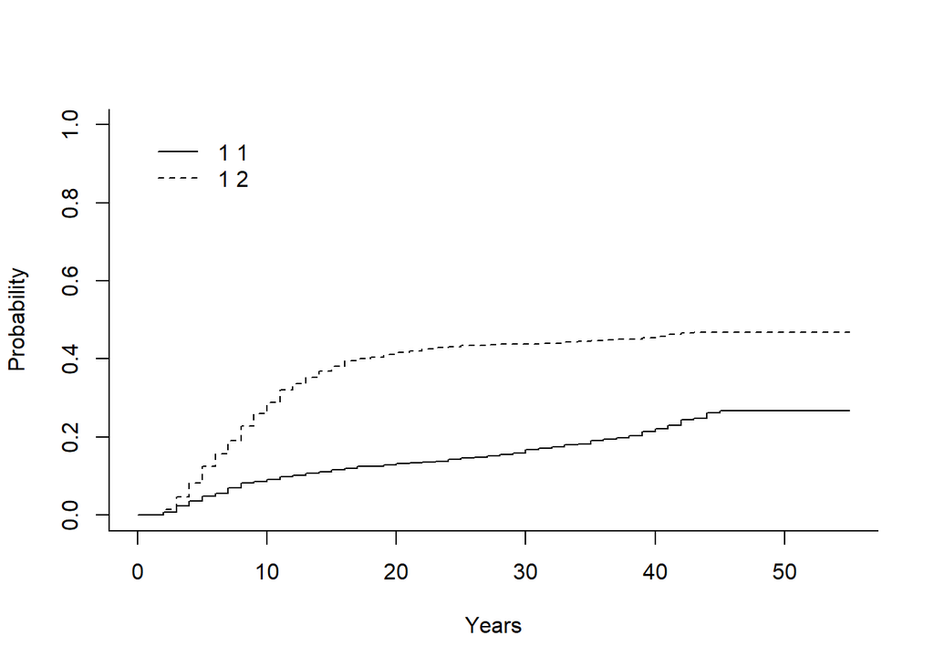

```r
plot(ic)
```

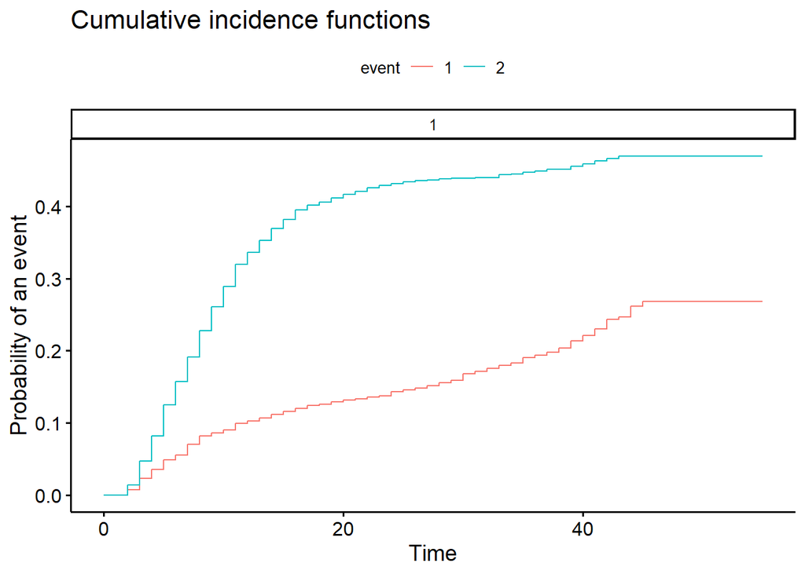

```r
ggcompetingrisks(fit = ic)
```

On compare les courbes en ajoutant l’option `groupe`, et ici on indique une version du test avec une pondération de type *Peto-Peto* avec `rho=1`. Pour le graphique avec `ggcompetingrisks` on a le choix entre avoir un graphique par valeur de la variable dont les valeurs sont comparées (graphique par défaut) ou un seul graphique avec les courbes empilées (option `multiple_panels = F`).

Le résultat du test de Gray est affiché automatiquement avec l’option `group`.

```r
ic = cuminc(act$dur, act$typinact, group=act$gene, rho=1)
ic
```

```
Tests:
      stat            pv df
1 17.20981 0.00018320456  2
2 21.10132 0.00002617622  2
Estimates and Variances:
$est
            10         20        30        40        50
2 1 0.08285888 0.11855967 0.1527784 0.2031056        NA
1 1 0.07317073 0.09963677 0.1312357 0.1715027 0.2041405
3 1 0.11186919 0.17086452 0.2136215 0.3303424        NA
2 2 0.34406102 0.45849678 0.4714256 0.4975086        NA
1 2 0.31097561 0.46976008 0.4969744 0.5173007 0.5307891
3 2 0.22926316 0.33783443 0.3629199 0.3728012        NA

$var
              10           20           30           40           50
2 1 0.0001907296 0.0002629734 0.0003287464 0.0004731326           NA
1 1 0.0001378102 0.0001821243 0.0002333418 0.0003029241 0.0004136609
3 1 0.0001819926 0.0002593861 0.0003156173 0.0026766240           NA
2 2 0.0005659435 0.0006240847 0.0006269723 0.0006856356           NA
1 2 0.0004347758 0.0005050285 0.0005082562 0.0005121396 0.0005289099
3 2 0.0003235388 0.0004092405 0.0004250576 0.0005095554           NA
```

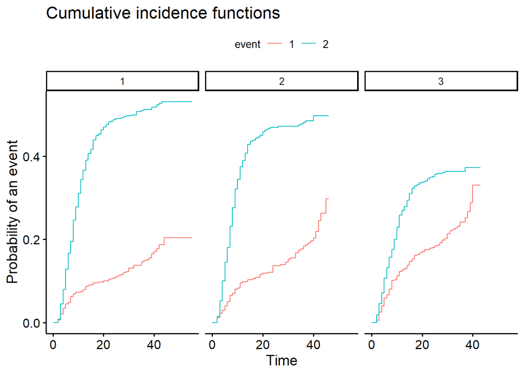

```r
ggcompetingrisks(fit = ic)
```

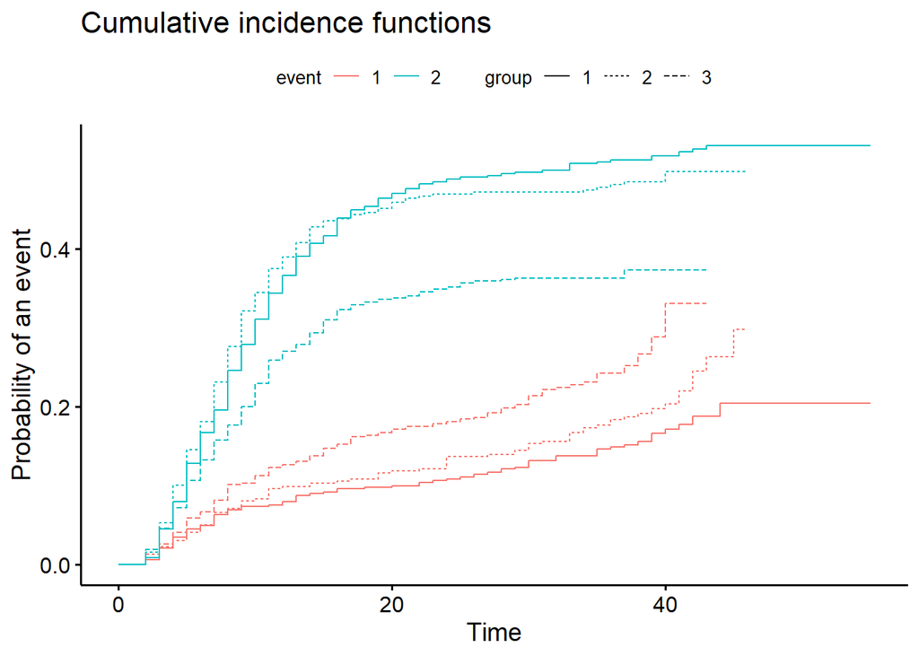

```r
ggcompetingrisks(fit = ic, multiple_panels = F)
```

# 7 Modèle multinomial

Bienvenue dans le monde de la librarie **`nnet`** et de la fonction très vieillissante **`multinom`**.

```r
act$T = act$dur
td = uncount(act,T)

td$gene = as.factor(td$gene)
td$gene =  relevel(td$gene, ref = "2")
td$csp  = as.factor(td$csp)
td$csp  =  relevel(td$csp,  ref = "Cadres")
td$diplome  = as.factor(td$diplome)
td$diplome =  relevel(td$diplome,  ref = 2)

td$typinact =  relevel(td$typinact, ref = "0")

td$x=1
td$t = ave(td$x, td$ident, FUN=cumsum)
td$t2 = td$t*td$t

td$e = ifelse(td$t<td$dur,0, td$typinact)

competfit = multinom(formula = e ~ t + t2 + gene + csp + diplome, data = td)
competfit
```

[output not shown]

PS: toujours du mal à sortir proprement avec Quarto l’output en utilisant gtsummary (normalement ok dans un script). Mais l’output n’est pas top non plus, les $Yk$ sont empilées en ligne alors qu’il est préférable de les mettre en colonne.

# 8 Mise en forme de la base

**Base additionnelle mef**

La base utilisée pour les analyses a été construite à partir d’une base individus-séquences. Pour obtenir les variables d’analyses (durée, évènement-censure) une mise en forme a été nécessaire. Il s’agit d’une méthode parmis d’autres, qui n’utilise que la base d’origine, et basée sur les comptages et doubles comptages des séquences pour conserver les informations nécessaires.  
Extrait de la base d’origine avec des situations types.

```r
mef <- read.csv("D:/D/Marc/SMS/FORMATIONS/2022/Durée2/a distribuer/mef.csv")
head(mef, n=29)
```

```
   ident age_enq ageact                 act_lab act
1    102      65     16                Activité   1
2    102      65     24                Activité   1
3    102      65     26                Activité   1
4    102      65     27 inactivité autre, foyer   4
5    102      65     60                retraite   7
6    113      62     14       études, formation   5
7    113      62     19                Activité   1
8    113      62     38                Activité   1
9    113      62     49                Activité   1
10   113      62     50                Activité   1
11   127      50     19                Activité   1
12   127      50     26                 chomage   2
13   127      50     27                Activité   1
14   127      50     28                Activité   1
15   127      50     29                Activité   1
16   127      50     30                Activité   1
17   132      63     17                Activité   1
18   132      63     25                Activité   1
19   132      63     26                Activité   1
20   132      63     27                Activité   1
21   132      63     30                Activité   1
22   132      63     34                Activité   1
23   132      63     35                Activité   1
24   132      63     46                Activité   1
25   132      63     47                Activité   1
26   132      63     49                Activité   1
27   132      63     56                Activité   1
28   132      63     57                Activité   1
29   132      63     60                retraite   7
```

- **ident=102**: Premier emploi à 16 ans, sortie définitive de l’emploi à 27 ans jusqu’à la retraite.
- **ident=113**: La première séquence n’est pas l’emploi (études/formation pro). Premier emploi à 19 ans. Toujours en activité au moment de l’enquête.
- **ident=127**: Premier emploi à 19 ans, suivi d’une période de chômage d’un an à l’âge de 26 ans. Toujours en activité depuis la reprise de l’emploi.
- **ident=132**: Premier emploi à 17 ans, et a toujours travaillé jusqu’à la retraite. Etait déjà à la retraite au moment de l’enquête: retraite à 60 ans et enquête à 63 ans.

## 8.1 On conserve les premières séquences = emploi

On supprime la première séquence de *ident=113* comme le début de l’exposition est l’âge au premier emploi.  
Idée: on repère si la première séquence observée est un emploi. Si ce n’est pas le cas, on supprime la ligne (*tact=0*).

```r
mef$act2 = ifelse(mef$act == 1, 1 , 0)
mef$tact = ave(mef$act2, mef$ident, FUN=cumsum)
mef = subset(mef, mef$tact>0)

mef$tact = NULL
```

## 8.2 Age à la 1ere séquence d’inactivité: retraite et autres causes de sortie

Même principe, mais on devra faire un double comptage pour la situation où après une période d’activité succède une période d’inactivité qui sera suivie d’une nouvelle séquence d’emploi, puis d’une nouvelle séquence de non emploi. C’est le cas pour *ident=127*. Avec **ttinact=1** on repère donc la première sortie de l’emploi.

```r
mef$inact = ifelse(mef$act != 1, 1 , 0)
mef$tinact = ave(mef$inact,  mef$ident, FUN=cumsum)
mef$ttinact = ave(mef$tinact, mef$ident, FUN=cumsum)
head(mef, n=29)
```

```
   ident age_enq ageact                 act_lab act act2 inact tinact ttinact
1    102      65     16                Activité   1    1     0      0       0
2    102      65     24                Activité   1    1     0      0       0
3    102      65     26                Activité   1    1     0      0       0
4    102      65     27 inactivité autre, foyer   4    0     1      1       1
5    102      65     60                retraite   7    0     1      2       3
7    113      62     19                Activité   1    1     0      0       0
8    113      62     38                Activité   1    1     0      0       0
9    113      62     49                Activité   1    1     0      0       0
10   113      62     50                Activité   1    1     0      0       0
11   127      50     19                Activité   1    1     0      0       0
12   127      50     26                 chomage   2    0     1      1       1
13   127      50     27                Activité   1    1     0      1       2
14   127      50     28                Activité   1    1     0      1       3
15   127      50     29                Activité   1    1     0      1       4
16   127      50     30                Activité   1    1     0      1       5
17   132      63     17                Activité   1    1     0      0       0
18   132      63     25                Activité   1    1     0      0       0
19   132      63     26                Activité   1    1     0      0       0
20   132      63     27                Activité   1    1     0      0       0
21   132      63     30                Activité   1    1     0      0       0
22   132      63     34                Activité   1    1     0      0       0
23   132      63     35                Activité   1    1     0      0       0
24   132      63     46                Activité   1    1     0      0       0
25   132      63     47                Activité   1    1     0      0       0
26   132      63     49                Activité   1    1     0      0       0
27   132      63     56                Activité   1    1     0      0       0
28   132      63     57                Activité   1    1     0      0       0
29   132      63     60                retraite   7    0     1      1       1
```

On reporte l’âge à la retraite si la retraite est la première séquence d’inactivité (ageinact avec act=7), ou l’âge à la sortie de l’emploi pour une autre cause (ageinact avec act différent de 7).

```r
mef$ageret =   ifelse(mef$ttinact==1 & mef$act==7, mef$ageact,0)
mef$ageinact = ifelse(mef$ttinact==1 & mef$act!=7, mef$ageact,0)
head(mef, n=29)
```

```
   ident age_enq ageact                 act_lab act act2 inact tinact ttinact
1    102      65     16                Activité   1    1     0      0       0
2    102      65     24                Activité   1    1     0      0       0
3    102      65     26                Activité   1    1     0      0       0
4    102      65     27 inactivité autre, foyer   4    0     1      1       1
5    102      65     60                retraite   7    0     1      2       3
7    113      62     19                Activité   1    1     0      0       0
8    113      62     38                Activité   1    1     0      0       0
9    113      62     49                Activité   1    1     0      0       0
10   113      62     50                Activité   1    1     0      0       0
11   127      50     19                Activité   1    1     0      0       0
12   127      50     26                 chomage   2    0     1      1       1
13   127      50     27                Activité   1    1     0      1       2
14   127      50     28                Activité   1    1     0      1       3
15   127      50     29                Activité   1    1     0      1       4
```

[output cut: 43 more lines]

On reporte les âges sur toutes les lignes en faisant un total, les âges avant la sortie étant toujours égaux à 0.

```r
mef$ageret   = ave(mef$ageret,   mef$ident, FUN=sum)
mef$ageinact = ave(mef$ageinact, mef$ident, FUN=sum)
head(mef, n=29)
```

```
   ident age_enq ageact                 act_lab act act2 inact tinact ttinact
1    102      65     16                Activité   1    1     0      0       0
2    102      65     24                Activité   1    1     0      0       0
3    102      65     26                Activité   1    1     0      0       0
4    102      65     27 inactivité autre, foyer   4    0     1      1       1
5    102      65     60                retraite   7    0     1      2       3
7    113      62     19                Activité   1    1     0      0       0
8    113      62     38                Activité   1    1     0      0       0
9    113      62     49                Activité   1    1     0      0       0
10   113      62     50                Activité   1    1     0      0       0
11   127      50     19                Activité   1    1     0      0       0
12   127      50     26                 chomage   2    0     1      1       1
13   127      50     27                Activité   1    1     0      1       2
14   127      50     28                Activité   1    1     0      1       3
15   127      50     29                Activité   1    1     0      1       4
```

[output cut: 43 more lines]

## 8.3 On conserve une ligne par individu

On génère un compteur sur les séquences, et on conserve seulement une ligne par personne.

```r
mef$x=1
mef$n = ave(mef$x, mef$ident, FUN=cumsum)
mef = subset(mef, mef$n==1)
mef = mef[c("ident","age_enq","ageact","act","ageret","ageinact")]
head(mef)
```

```
   ident age_enq ageact act ageret ageinact
1    102      65     16   1      0       27
7    113      62     19   1      0        0
11   127      50     19   1      0       26
17   132      63     17   1     60        0
```